# Тестовое задание на соискание должности исследователя "Белка Диджитал"

### Обучение случайного леса

```python
%%time
model = RandomForestRegressor(random_state=RANDOM_STATE)
param_grid={
              'model__max_depth':list(range(1, 15, 4)),
              'model__n_estimators':list(range(1, 11, 3))
           }

model_rfr = make_grid_search(model, param_grid, features_train, target_train)
```

```
Fitting 5 folds for each of 16 candidates, totalling 80 fits
[CV] END ..........model__max_depth=1, model__n_estimators=1; total time=   0.0s
[CV] END ..........model__max_depth=1, model__n_estimators=1; total time=   0.0s
[CV] END ..........model__max_depth=1, model__n_estimators=1; total time=   0.0s
[CV] END ..........model__max_depth=1, model__n_estimators=1; total time=   0.0s
[CV] END ..........model__max_depth=1, model__n_estimators=1; total time=   0.0s
[CV] END ..........model__max_depth=1, model__n_estimators=4; total time=   0.0s
[CV] END ..........model__max_depth=1, model__n_estimators=4; total time=   0.0s
[CV] END ..........model__max_depth=1, model__n_estimators=4; total time=   0.0s
[CV] END ..........model__max_depth=1, model__n_estimators=4; total time=   0.0s
[CV] END ..........model__max_depth=1, model__n_estimators=4; total time=   0.0s
[CV] END ..........model__max_depth=1, model__n_estimators=7; total time=   0.0s
[CV] END ..........model__max_depth=1, model__n_estimators=7; total time=   0.0s
[CV] END ..........model__max_depth=1, model__n_estimators=7; total time=   0.0s
[CV] END ..........model__max_depth=1, model__n_estimators=7; total time=   0.0s
[CV] END ..........model__max_depth=1, model__n_estimators=7; total time=   0.0s
[CV] END .........model__max_depth=1, model__n_estimators=10; total time=   0.0s
[CV] END .........model__max_depth=1, model__n_estimators=10; total time=   0.0s
[CV] END .........model__max_depth=1, model__n_estimators=10; total time=   0.0s
[CV] END .........model__max_depth=1, model__n_estimators=10; total time=   0.0s
[CV] END .........model__max_depth=1, model__n_estimators=10; total time=   0.0s
[CV] END ..........model__max_depth=5, model__n_estimators=1; total time=   0.0s
[CV] END ..........model__max_depth=5, model__n_estimators=1; total time=   0.0s
[CV] END ..........model__max_depth=5, model__n_estimators=1; total time=   0.0s
[CV] END ..........model__max_depth=5, model__n_estimators=1; total time=   0.0s
[CV] END ..........model__max_depth=5, model__n_estimators=1; total time=   0.0s
[CV] END ..........model__max_depth=5, model__n_estimators=4; total time=   0.0s
[CV] END ..........model__max_depth=5, model__n_estimators=4; total time=   0.0s
[CV] END ..........model__max_depth=5, model__n_estimators=4; total time=   0.0s
[CV] END ..........model__max_depth=5, model__n_estimators=4; total time=   0.0s
[CV] END ..........model__max_depth=5, model__n_estimators=4; total time=   0.0s
[CV] END ..........model__max_depth=5, model__n_estimators=7; total time=   0.0s
[CV] END ..........model__max_depth=5, model__n_estimators=7; total time=   0.0s
[CV] END ..........model__max_depth=5, model__n_estimators=7; total time=   0.0s
[CV] END ..........model__max_depth=5, model__n_estimators=7; total time=   0.0s
[CV] END ..........model__max_depth=5, model__n_estimators=7; total time=   0.0s
[CV] END .........model__max_depth=5, model__n_estimators=10; total time=   0.0s
[CV] END .........model__max_depth=5, model__n_estimators=10; total time=   0.0s
[CV] END .........model__max_depth=5, model__n_estimators=10; total time=   0.0s
[CV] END .........model__max_depth=5, model__n_estimators=10; total time=   0.0s
```

[output cut: 32 more lines]

```
[CV] END .........model__max_depth=13, model__n_estimators=7; total time=   0.0s
[CV] END .........model__max_depth=13, model__n_estimators=7; total time=   0.0s
[CV] END .........model__max_depth=13, model__n_estimators=7; total time=   0.0s
[CV] END .........model__max_depth=13, model__n_estimators=7; total time=   0.0s
[CV] END ........model__max_depth=13, model__n_estimators=10; total time=   0.0s
[CV] END ........model__max_depth=13, model__n_estimators=10; total time=   0.0s
[CV] END ........model__max_depth=13, model__n_estimators=10; total time=   0.0s
[CV] END ........model__max_depth=13, model__n_estimators=10; total time=   0.0s
[CV] END ........model__max_depth=13, model__n_estimators=10; total time=   0.0s
Лучшие параметры модели:
{'model__max_depth': 5, 'model__n_estimators': 7}
----------
Оценка RMSE модели: -946.603
CPU times: total: 2 s
Wall time: 2.69 s
```

### Обучение модели градиентного бустинга CatBoostRegressor

```python
%%time
model = CatBoostRegressor(loss_function="RMSE", iterations=100, random_state=RANDOM_STATE, verbose=0)
param_grid={
              'model__depth':list(range(1, 15, 4)),
              'model__learning_rate':list([x/10 for x in range(1, 11, 4)])
           }

model_cbr = make_grid_search(model, param_grid, features_train, target_train)
```

```
Fitting 5 folds for each of 12 candidates, totalling 60 fits
[CV] END ...........model__depth=1, model__learning_rate=0.1; total time=   0.8s
[CV] END ...........model__depth=1, model__learning_rate=0.1; total time=   0.0s
[CV] END ...........model__depth=1, model__learning_rate=0.1; total time=   0.0s
[CV] END ...........model__depth=1, model__learning_rate=0.1; total time=   0.0s
[CV] END ...........model__depth=1, model__learning_rate=0.1; total time=   0.0s
[CV] END ...........model__depth=1, model__learning_rate=0.5; total time=   0.0s
[CV] END ...........model__depth=1, model__learning_rate=0.5; total time=   0.0s
[CV] END ...........model__depth=1, model__learning_rate=0.5; total time=   0.0s
[CV] END ...........model__depth=1, model__learning_rate=0.5; total time=   0.0s
[CV] END ...........model__depth=1, model__learning_rate=0.5; total time=   0.0s
[CV] END ...........model__depth=1, model__learning_rate=0.9; total time=   0.0s
[CV] END ...........model__depth=1, model__learning_rate=0.9; total time=   0.0s
[CV] END ...........model__depth=1, model__learning_rate=0.9; total time=   0.0s
[CV] END ...........model__depth=1, model__learning_rate=0.9; total time=   0.0s
[CV] END ...........model__depth=1, model__learning_rate=0.9; total time=   0.0s
[CV] END ...........model__depth=5, model__learning_rate=0.1; total time=   0.0s
[CV] END ...........model__depth=5, model__learning_rate=0.1; total time=   0.0s
[CV] END ...........model__depth=5, model__learning_rate=0.1; total time=   0.1s
[CV] END ...........model__depth=5, model__learning_rate=0.1; total time=   0.0s
[CV] END ...........model__depth=5, model__learning_rate=0.1; total time=   0.0s
[CV] END ...........model__depth=5, model__learning_rate=0.5; total time=   0.0s
[CV] END ...........model__depth=5, model__learning_rate=0.5; total time=   0.1s
[CV] END ...........model__depth=5, model__learning_rate=0.5; total time=   0.0s
[CV] END ...........model__depth=5, model__learning_rate=0.5; total time=   0.0s
[CV] END ...........model__depth=5, model__learning_rate=0.5; total time=   0.0s
[CV] END ...........model__depth=5, model__learning_rate=0.9; total time=   0.2s
[CV] END ...........model__depth=5, model__learning_rate=0.9; total time=   0.0s
[CV] END ...........model__depth=5, model__learning_rate=0.9; total time=   0.0s
[CV] END ...........model__depth=5, model__learning_rate=0.9; total time=   0.0s
[CV] END ...........model__depth=5, model__learning_rate=0.9; total time=   0.0s
[CV] END ...........model__depth=9, model__learning_rate=0.1; total time=   0.4s
[CV] END ...........model__depth=9, model__learning_rate=0.1; total time=   0.4s
[CV] END ...........model__depth=9, model__learning_rate=0.1; total time=   0.4s
[CV] END ...........model__depth=9, model__learning_rate=0.1; total time=   0.4s
[CV] END ...........model__depth=9, model__learning_rate=0.1; total time=   0.5s
[CV] END ...........model__depth=9, model__learning_rate=0.5; total time=   0.6s
[CV] END ...........model__depth=9, model__learning_rate=0.5; total time=   0.5s
[CV] END ...........model__depth=9, model__learning_rate=0.5; total time=   0.5s
[CV] END ...........model__depth=9, model__learning_rate=0.5; total time=   0.7s
```

[output cut: 12 more lines]

```
[CV] END ..........model__depth=13, model__learning_rate=0.5; total time=   7.0s
[CV] END ..........model__depth=13, model__learning_rate=0.5; total time=   6.4s
[CV] END ..........model__depth=13, model__learning_rate=0.5; total time=   6.9s
[CV] END ..........model__depth=13, model__learning_rate=0.5; total time=   7.1s
[CV] END ..........model__depth=13, model__learning_rate=0.9; total time=   7.4s
[CV] END ..........model__depth=13, model__learning_rate=0.9; total time=   7.3s
[CV] END ..........model__depth=13, model__learning_rate=0.9; total time=   6.3s
[CV] END ..........model__depth=13, model__learning_rate=0.9; total time=   7.6s
[CV] END ..........model__depth=13, model__learning_rate=0.9; total time=   7.1s
Лучшие параметры модели:
{'model__depth': 9, 'model__learning_rate': 0.1}
----------
Оценка RMSE модели: -865.724
CPU times: total: 1min 54s
Wall time: 1min 59s
```

### Выводы по обучению моделей

Наилучший результат с минимальным значением RMSE равным 866 показала модель градиентного бустинга CatBoostRegressor. Перейдем к ее тестированию.

## Тестирование

```python
predictions_test = model_cbr.predict(features_test)

result = mean_squared_error(target_test, predictions_test)**0.5
print(result)
```

```
873.6687929304547
```

Модель CatBoostRegressor показала значение метрики RMSE равным 874.

Обучим модель на полном наборе данных - тренировочная выборка плюс тестовая выборка:

```python
%%time
model = CatBoostRegressor(loss_function="RMSE", iterations=100, random_state=RANDOM_STATE, verbose=0)
param_grid={
              'model__depth':list(range(1, 15, 2)),
              'model__learning_rate':list([x/10 for x in range(1, 11, 4)])
           }

model_cbr = make_grid_search(model, param_grid, features, target)
```

```
Fitting 5 folds for each of 21 candidates, totalling 105 fits
[CV] END ...........model__depth=1, model__learning_rate=0.1; total time=   0.0s
[CV] END ...........model__depth=1, model__learning_rate=0.1; total time=   0.0s
[CV] END ...........model__depth=1, model__learning_rate=0.1; total time=   0.0s
[CV] END ...........model__depth=1, model__learning_rate=0.1; total time=   0.0s
[CV] END ...........model__depth=1, model__learning_rate=0.1; total time=   0.0s
[CV] END ...........model__depth=1, model__learning_rate=0.5; total time=   0.0s
[CV] END ...........model__depth=1, model__learning_rate=0.5; total time=   0.0s
[CV] END ...........model__depth=1, model__learning_rate=0.5; total time=   0.0s
[CV] END ...........model__depth=1, model__learning_rate=0.5; total time=   0.0s
[CV] END ...........model__depth=1, model__learning_rate=0.5; total time=   0.0s
[CV] END ...........model__depth=1, model__learning_rate=0.9; total time=   0.0s
[CV] END ...........model__depth=1, model__learning_rate=0.9; total time=   0.0s
[CV] END ...........model__depth=1, model__learning_rate=0.9; total time=   0.0s
[CV] END ...........model__depth=1, model__learning_rate=0.9; total time=   0.0s
[CV] END ...........model__depth=1, model__learning_rate=0.9; total time=   0.0s
[CV] END ...........model__depth=3, model__learning_rate=0.1; total time=   0.0s
[CV] END ...........model__depth=3, model__learning_rate=0.1; total time=   0.0s
[CV] END ...........model__depth=3, model__learning_rate=0.1; total time=   0.0s
[CV] END ...........model__depth=3, model__learning_rate=0.1; total time=   0.0s
[CV] END ...........model__depth=3, model__learning_rate=0.1; total time=   0.0s
[CV] END ...........model__depth=3, model__learning_rate=0.5; total time=   0.0s
[CV] END ...........model__depth=3, model__learning_rate=0.5; total time=   0.0s
[CV] END ...........model__depth=3, model__learning_rate=0.5; total time=   0.0s
[CV] END ...........model__depth=3, model__learning_rate=0.5; total time=   0.0s
[CV] END ...........model__depth=3, model__learning_rate=0.5; total time=   0.0s
[CV] END ...........model__depth=3, model__learning_rate=0.9; total time=   0.0s
[CV] END ...........model__depth=3, model__learning_rate=0.9; total time=   0.0s
[CV] END ...........model__depth=3, model__learning_rate=0.9; total time=   0.0s
[CV] END ...........model__depth=3, model__learning_rate=0.9; total time=   0.0s
[CV] END ...........model__depth=3, model__learning_rate=0.9; total time=   0.0s
[CV] END ...........model__depth=5, model__learning_rate=0.1; total time=   0.0s
[CV] END ...........model__depth=5, model__learning_rate=0.1; total time=   0.0s
[CV] END ...........model__depth=5, model__learning_rate=0.1; total time=   0.0s
[CV] END ...........model__depth=5, model__learning_rate=0.1; total time=   0.0s
[CV] END ...........model__depth=5, model__learning_rate=0.1; total time=   0.0s
[CV] END ...........model__depth=5, model__learning_rate=0.5; total time=   0.0s
[CV] END ...........model__depth=5, model__learning_rate=0.5; total time=   0.0s
[CV] END ...........model__depth=5, model__learning_rate=0.5; total time=   0.0s
[CV] END ...........model__depth=5, model__learning_rate=0.5; total time=   0.0s
```

[output cut: 57 more lines]

```
[CV] END ..........model__depth=13, model__learning_rate=0.5; total time=   9.2s
[CV] END ..........model__depth=13, model__learning_rate=0.5; total time=   8.3s
[CV] END ..........model__depth=13, model__learning_rate=0.5; total time=   9.0s
[CV] END ..........model__depth=13, model__learning_rate=0.5; total time=   8.7s
[CV] END ..........model__depth=13, model__learning_rate=0.9; total time=   9.0s
[CV] END ..........model__depth=13, model__learning_rate=0.9; total time=   9.9s
[CV] END ..........model__depth=13, model__learning_rate=0.9; total time=   8.6s
[CV] END ..........model__depth=13, model__learning_rate=0.9; total time=   9.1s
[CV] END ..........model__depth=13, model__learning_rate=0.9; total time=   8.8s
Лучшие параметры модели:
{'model__depth': 9, 'model__learning_rate': 0.1}
----------
Оценка RMSE модели: -876.435
CPU times: total: 2min 58s
Wall time: 3min 3s
```

Проанализируем модель

```python
data_predict = data.copy()
data_predict['predict_percon'] = abs(
    100 * (model_cbr.predict(data.drop('price', axis=1)) - data['price']) / data['price']
)
```

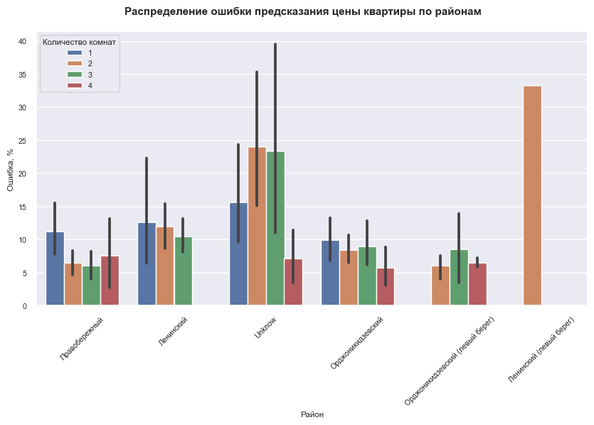

```python
fig = plt.figure(figsize=[10, 5])
ax = fig.add_subplot()
fig.suptitle('Распределение ошибки предсказания цены квартиры по районам', fontsize=11, fontweight='bold', y=0.95)
sns.barplot(data=data_predict, x='region', y='predict_percon', hue='rooms')
ax.set(xlabel='Район', ylabel='Ошибка, %')
ax.legend(title="Количество комнат")
plt.xticks(rotation = 45)
plt.show();
```

Из графика видно, что для двухкомнатных квартир из Ленинского (левый берег) района модель ошибается более чем на 30%. Это связано с тем что по данному району мало данных, поэтому выборка получается не репрезетативная. Стоимость однокомнатных, двухкомнатных и трехкомнатных квартир хуже всего пресказываются в неизвестном районе - Unknow. Ошибки предсказания стоимости квартир по остальным районам сопоставимы.

Сохраним модель в файл

```python
joblib.dump(model_cbr, 'model_cbr.pkl')
```

```
['model_cbr.pkl']
```